# Assignment1: CancerMortality

Joan Acero, Anna Monsó, Walter Troiani

2024-10-21

# Load the dataset and required libraries

```r
rm(list=ls())
knitr::opts_chunk$set(fig.align='center', out.width='50%') # Manage output plots width and align

train <- read.csv("train.csv")
test <- read.csv("test.csv")

library(moments)
library(car)
```

# Define some functions to avoid repetition of same processes

```r
calculate_outliers <- function(data) {
  # Check for regular outliers
  outliers <- boxplot.stats(data)$out
  num_outliers <- length(outliers)

  # Calculate the lower and upper bounds for severe outliers
  Q1 <- quantile(data, 0.25, na.rm = TRUE)
  Q3 <- quantile(data, 0.75, na.rm = TRUE)
  IQR <- Q3 - Q1

  lower_severe_bound <- Q1 - 3 * IQR
  upper_severe_bound <- Q3 + 3 * IQR

  # Identify severe outliers
  severe_outliers <- data[data < lower_severe_bound | data > upper_severe_bound]
  num_severe_outliers <- length(severe_outliers)

  # Return the results as a list
  return(list(
    num_outliers = num_outliers,
    num_severe_outliers = num_severe_outliers
  ))
}

summary_and_normality_check <- function(data) {
  #Basic summary
  print("Summary: ")
  print(summary(data))

  # Plot normality
  print("Mean")
  mm <- mean(data); print(mm)
  print("Standard deviation")
  ss <- sd(data); print(ss)
  hist(data,freq = F,100, main = "Histogram")
  curve(dnorm(x, mean = mm, sd = ss),col="red", lwd = 2, add=T)

  #Compute skewness
  print("Skewness")
  print(skewness(data))

  #Number of outliers
  print("Outliers: ")
  print(calculate_outliers(data))

  #Shapiro test
  print("Shapiro test: ")
  print(shapiro.test(data))

}
```

# Data Preparation

In this section, a descriptive analysis is conducted on each variable, a data quality report is generated, and imputation and profiling are addressed.

## Univariate Descriptive Analysis (Variable Analysis)

- Original numeric variables corresponding to qualitative concepts have to be converted to factors:
- Original numeric variables corresponding to real quantitative concepts are kept as numeric but additional factors should also be created
- Exploratory Data Analysis for each variable (numeric summary and graphic support) of the train sample.

### Variable *avganncount*

*avganncount* is a numerical variable representing the “Mean number of reported cancer cases diagnosed annually (2010-2015).” The difference between the mean (623.2) and the median (175) indicates that the distribution is not symmetric and deviates from normality. Additionally, the first and third quartiles (80 and 509, respectively) are much lower than the mean of 623.2 and the maximum value of 38150.0, further suggesting skewness. The boxplot confirms this skewness, with an extended upper whisker and numerous outliers, indicating a heavy right tail. It has 273 outliers, and 224 of these are severe outliers.

The histogram overlaid with a normal curve highlights the deviation from a normal distribution with the same mean and standard deviation. This variable has no missing values. Lastly, the skeweness indicator and Shapiro test rejection of the null hypothesis also confirm the non-normal distribution of the variable.

```r
variable <- train$avganncount
summary <- summary(variable); summary
```

```
##    Min. 1st Qu.  Median    Mean 3rd Qu.    Max.
##     7.0    80.0   175.0   623.2   509.0 38150.0
```

```r
variable[variable == 453.5494221] <- NA
summary <- summary(variable); summary
```

```
##    Min. 1st Qu.  Median    Mean 3rd Qu.    Max.
##     7.0    80.0   175.0   623.2   509.0 38150.0
```

```r
mm <- mean(variable)
ss <- sd(variable)
range <- (summary[[6]] - summary[[1]]); range
```

```
## [1] 38143
```

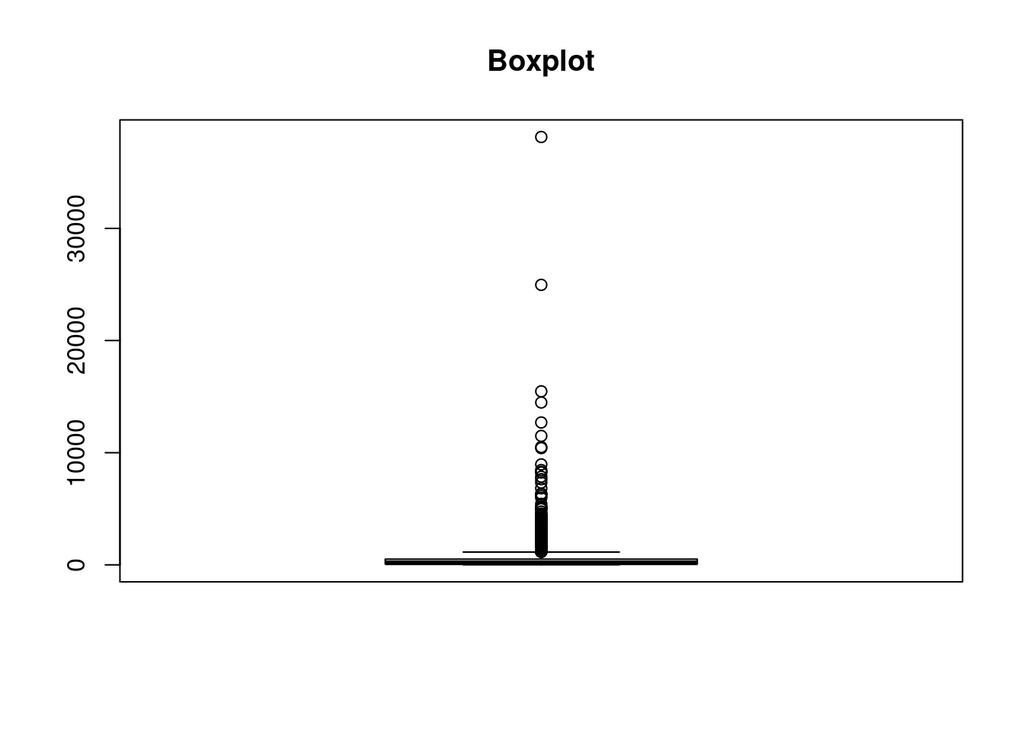

```r
boxplot(variable, main = "Boxplot")
```

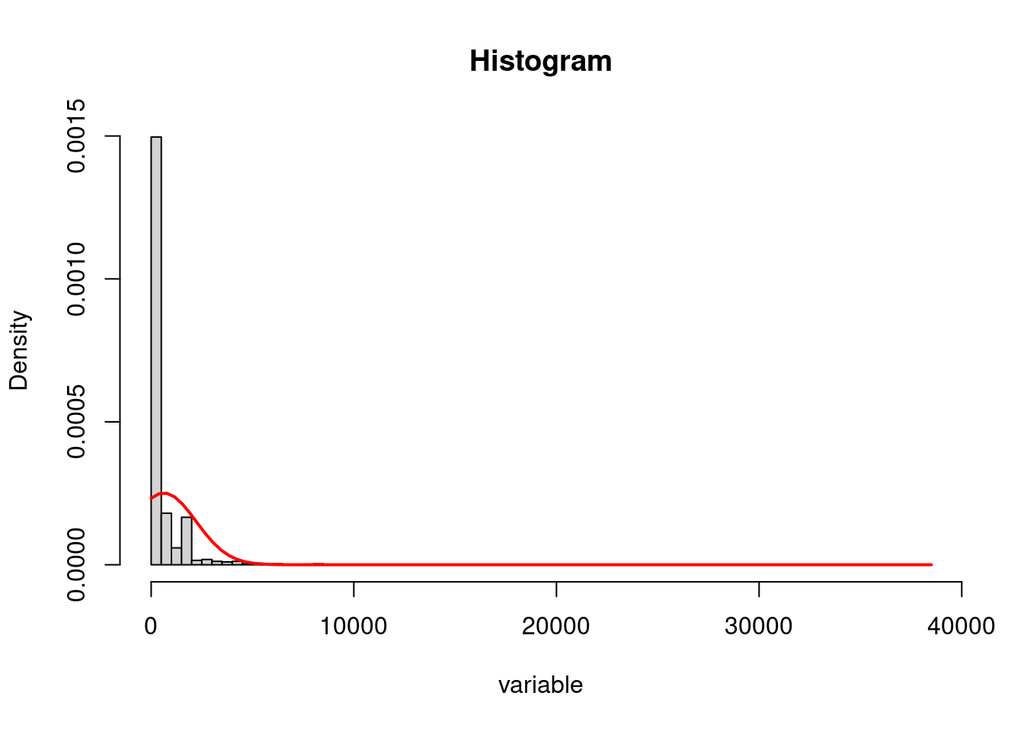

```r
hist(variable,freq = F,100, main = "Histogram")
curve(dnorm(x, mean = mm, sd = ss),col="red", lwd = 2, add=T)
```

```r
shapiro.test(variable)
```

```
##
##  Shapiro-Wilk normality test
##
## data:  variable
## W = 0.33377, p-value < 2.2e-16
```

```r
calculate_outliers(variable)
```

```
## $num_outliers
## [1] 273
##
## $num_severe_outliers
## [1] 224
```

```r
variable <- train$avganncount
summary <- summary(train$avganncount); summary
```

```
##    Min. 1st Qu.  Median    Mean 3rd Qu.    Max.
##     7.0    80.0   175.0   623.2   509.0 38150.0
```

```r
mm <- mean(train$avganncount)
ss <- sd(train$avganncount)
range <- (summary[[6]] - summary[[1]]); range
```

```
## [1] 38143
```

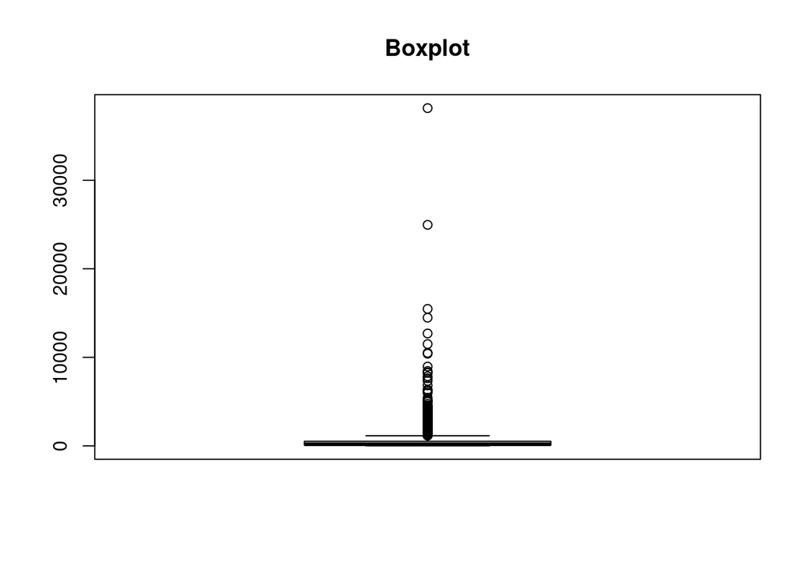

```r
boxplot(train$avganncount, main= "Boxplot")
```

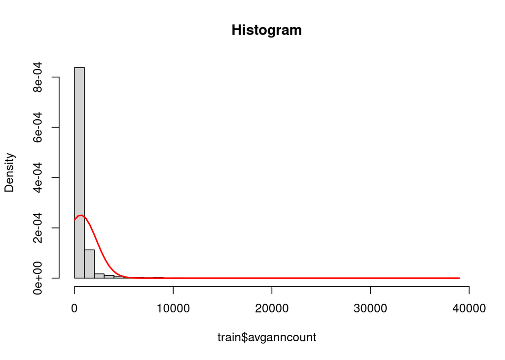

```r
hist(train$avganncount,freq = F,30, main = "Histogram")
curve(dnorm(x, mean = mm, sd = ss),col="red", lwd = 2, add=T)
```

```r
skewness(train$avganncount)
```

```
## [1] 11.48879
```

```r
shapiro.test(train$avganncount)
```

```
##
##  Shapiro-Wilk normality test
##
## data:  train$avganncount
## W = 0.33377, p-value < 2.2e-16
```

```r
calculate_outliers(train$avganncount)
```

```
## $num_outliers
## [1] 273
##
## $num_severe_outliers
## [1] 224
```

### Variable *avgdeathsperyear*

In a similar way, *avgdeathsperyear* is a numerical variable expressing the “Mean number of reported mortalities due to cancer”.

It has no missing values. The difference between the mean (191.6) and median (62) indicates that the distribution is not symmetric. Moreover, the first and third quartiles (29 and 140.5, respectivelly) are lower than the mean and the maximum value of 14010, further suggesting a skewed ditribution. With the help of graphical tools like the boxplot we can confirm the skeweness, obtaining 225 outliers (138 of which are severe), indicating a large right tail. The histogram overlaid with a normal curve highlights the deviation from a normal distribution with the same mean and standard deviation, and the Shapiro test also confirms the non-normality of the variable.

```r
variable <- train$avgdeathsperyear;
summary <- summary(variable);summary
```

```
##    Min. 1st Qu.  Median    Mean 3rd Qu.    Max.
##     3.0    29.0    62.0   191.6   140.5 14010.0
```

```r
mm <- mean(variable)
ss <- sd(variable)
range <- (summary[[6]] - summary[[1]]); range
```

```
## [1] 14007
```

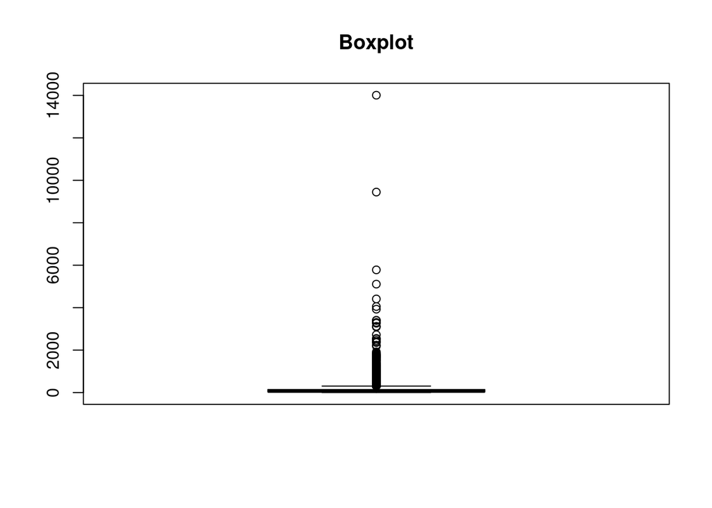

```r
boxplot(variable, main = "Boxplot")
```

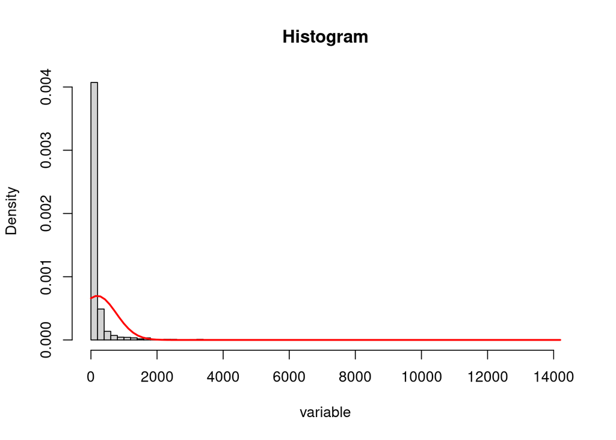

```r
hist(variable,freq = F,100, main = "Histogram")
curve(dnorm(x, mean = mm, sd = ss),col="red", lwd = 2, add=T)
```

```r
skewness(variable)
```

```
## [1] 12.4999
```

```r
shapiro.test(variable)
```

```
##
##  Shapiro-Wilk normality test
##
## data:  variable
## W = 0.26769, p-value < 2.2e-16
```

```r
calculate_outliers(variable)
```

```
## $num_outliers
## [1] 225
##
## $num_severe_outliers
## [1] 138
```

### Variable *target_deathrate* :

Variable *target_deathrate* is a numerical variable that is the target of the model. It contains no missing values in the train sample. The median (178.3) and mean (178.8) values are really close, expressing the symmetry of the distribution of the variable. Thanks to the boxplot and the histogram we can graphically confirm the symmetry of the distribution.

We performed the Shapiro test to check for the normality of the data, and obtained a small p-value that rejects the null hypothesis, indicating that the variable does not follow a normal distribution. Therefore, the target variable is not normally distributed.

Moreover, it contains 35 outliers, 1 of which is a severe.

```r
variable <- train$target_deathrate;
summary <- summary(variable); summary
```

```
##    Min. 1st Qu.  Median    Mean 3rd Qu.    Max.
##    59.7   161.3   178.3   178.8   195.3   362.8
```

```r
mm <- mean(variable)
ss <- sd(variable)
range <- (summary[[6]] - summary[[1]]); range
```

```
## [1] 303.1
```

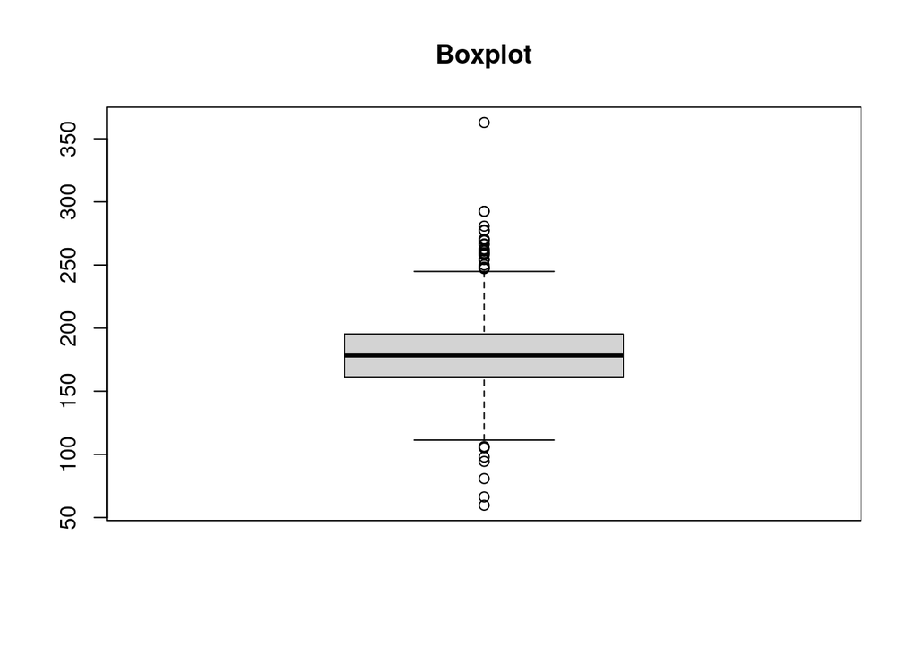

```r
boxplot(variable, main = "Boxplot")
```

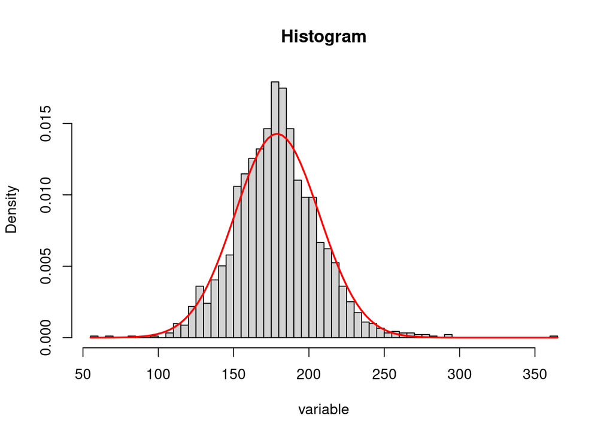

```r
hist(variable,freq = F,100, main = "Histogram")
curve(dnorm(x, mean = mm, sd = ss),col="red", lwd = 2, add=T)
```

```r
skewness(variable)
```

```
## [1] 0.3243216
```

```r
shapiro.test(variable)
```

```
##
##  Shapiro-Wilk normality test
##
## data:  variable
## W = 0.98647, p-value = 4.149e-12
```

```r
calculate_outliers(variable)
```

```
## $num_outliers
## [1] 35
##
## $num_severe_outliers
## [1] 1
```

### Variable *incidencerate* :

Variable *incidencerate* is a numerical variable that expresses “Mean per capita (100,000) cancer diagnoses”.

– anna – In this variable there are 126 values = “453.5494221” we should consider these as NA (same rows as avganncount variable)

```r
variable <- train$incidencerate;
summary <- summary(variable); summary
```

```
##    Min. 1st Qu.  Median    Mean 3rd Qu.    Max.
##   201.3   421.4   453.5   449.0   481.3  1206.9
```

```r
variable[variable == 453.5494221] <- NA
summary <- summary(variable); summary
```

```
##    Min. 1st Qu.  Median    Mean 3rd Qu.    Max.    NA's
##   201.3   417.5   451.8   448.7   483.8  1206.9     126
```

```r
mm <- mean(variable)
ss <- sd(variable)
range <- (summary[[6]] - summary[[1]]); range
```

```
## [1] 1005.6
```

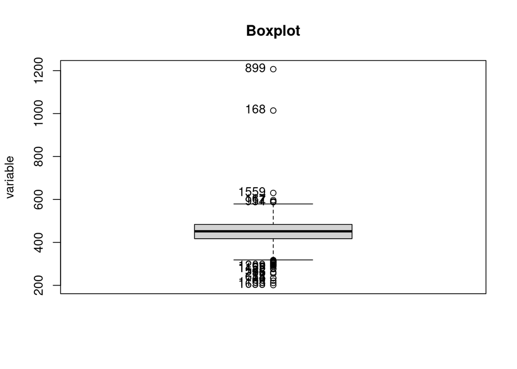

```
##  [1] 1633 1168   60   18  634  295  558 1122 1155 1209   17  167  168  899  954
## [16] 1559
```

```r
Boxplot(variable, main = "Boxplot")
```

```r
train[889,"geography"]
```

```
## [1] "Osceola County, Florida"
```

```r
train[168, "geography"]
```

```
## [1] "Williamsburg city, Virginia"
```

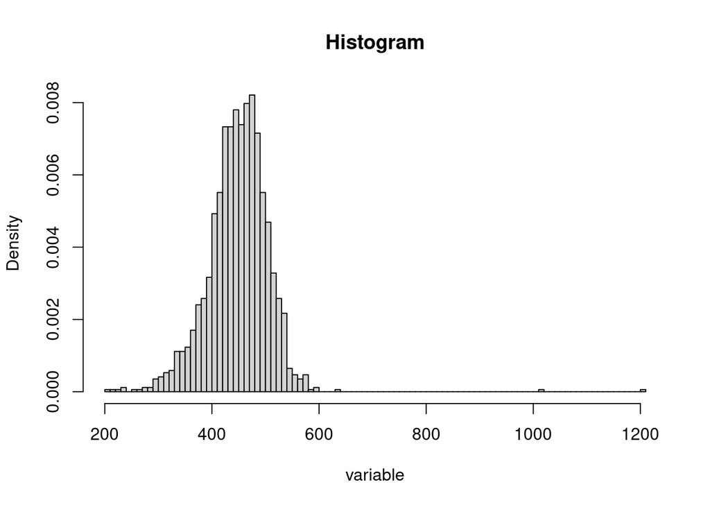

```r
hist(variable,freq = F,100, main = "Histogram")
curve(dnorm(x, mean = mm, sd = ss),col="red", lwd = 2, add=T)
```

```r
skewness(variable)
```

```
## [1] NA
```

```r
shapiro.test(variable)
```

```
##
##  Shapiro-Wilk normality test
##
## data:  variable
## W = 0.90204, p-value < 2.2e-16
```

```r
calculate_outliers(variable)
```

```
## $num_outliers
## [1] 36
##
## $num_severe_outliers
## [1] 130
```

### Variable *medincome* :

Variable *medincome* is a numerical variable that expresses the “Median income per county”.

Thanks to the histogram, Shapiro test, and skeweness value, we see how the distribution is neither Normal nor symmetric, but it is skewed with a long right tail. It has 69 outliers, 15 of them severe. The highest value is for Loudoun County, Virginia. There are no missing values in this variable.

```r
variable <- train$medincome;
summary <- summary(variable); summary
```

```
##    Min. 1st Qu.  Median    Mean 3rd Qu.    Max.
##   22640   39031   45454   47278   52612  122641
```

```r
mm <- mean(variable)
ss <- sd(variable)
range <- (summary[[6]] - summary[[1]]); range
```

```
## [1] 100001
```

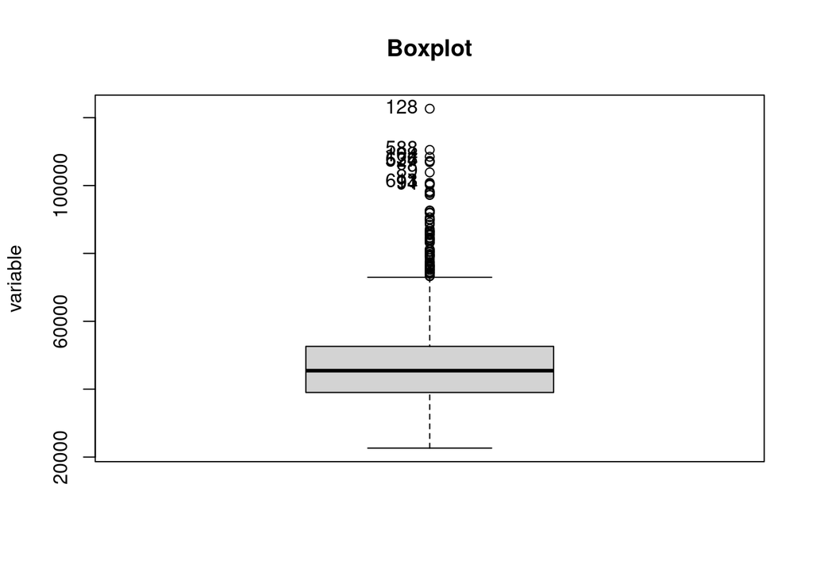

```
##  [1] 128 588 104 636 574 527  89 613  91  94
```

```r
Boxplot(variable, main = "Boxplot")
```

```r
train$geography[128] # Virginia
```

```
## [1] "Loudoun County, Virginia"
```

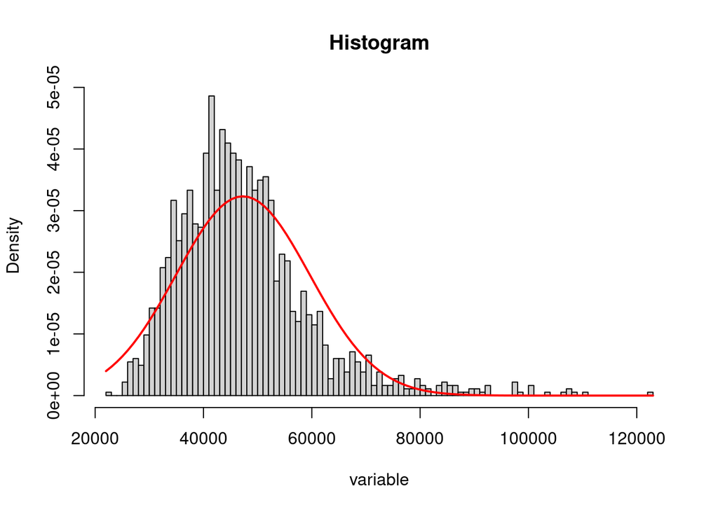

```r
hist(variable,freq = F,100, main = "Histogram")
curve(dnorm(x, mean = mm, sd = ss),col="red", lwd = 2, add=T)
```

```r
skewness(variable)
```

```
## [1] 1.466811
```

```r
shapiro.test(variable)
```

```
##
##  Shapiro-Wilk normality test
##
## data:  variable
## W = 0.9105, p-value < 2.2e-16
```

```r
calculate_outliers(variable)
```

```
## $num_outliers
## [1] 69
##
## $num_severe_outliers
## [1] 15
```

### Variable *popest2015* :

Variable *popest2015* is a numerical variable that expresses the population of the county.

It does not count with missing values. It has a long range and is highly skewed, with a long right tail. In fact, it contains 252 outliers, 162 of which are severe, and all of them are above the upper whisker in the boxplot. The highest value is for Los Angeles County, California. The large difference between the mean (106.841) and median (27.158), along with the spread between the 1st (12.191) and 3rd quartiles (66.880), indicates a positively skewed distribution, where extreme high values are pulling the mean upward.

```r
variable <- train$popest2015;
summary <- summary(variable); summary
```

```
##     Min.  1st Qu.   Median     Mean  3rd Qu.     Max.
##      829    12191    27158   106841    66880 10170292
```

```r
mm <- mean(variable)
ss <- sd(variable)
range <- (summary[[6]] - summary[[1]]); range
```

```
## [1] 10169463
```

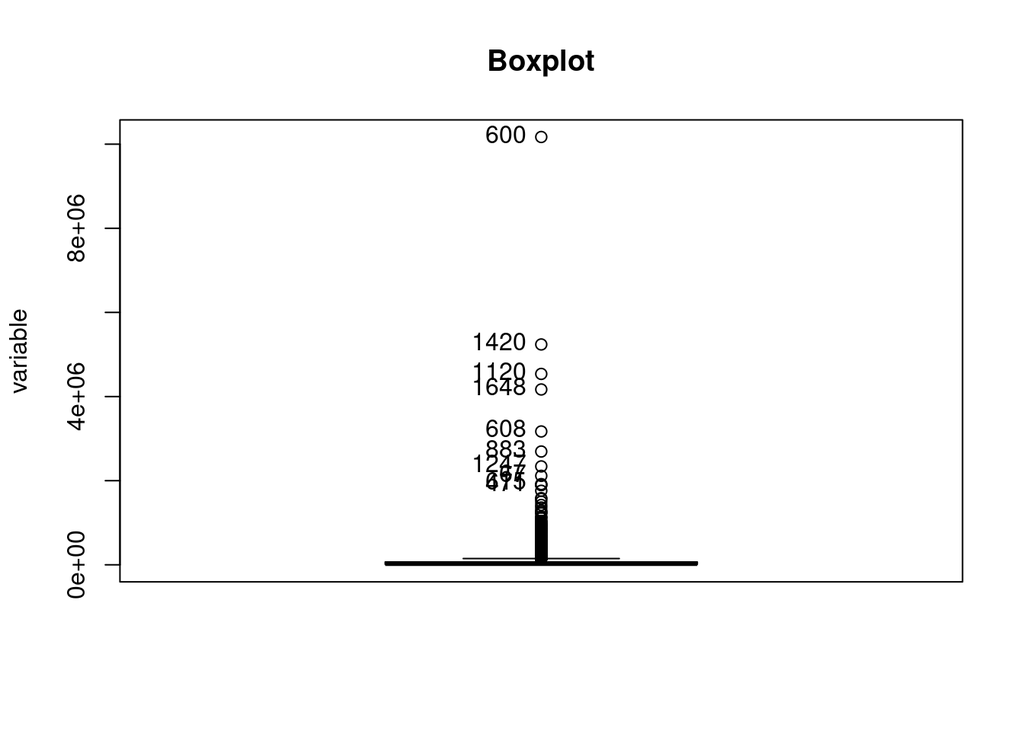

```
##  [1]  600 1420 1120 1648  608  883 1247   67  615  471
```

```r
Boxplot(variable, main = "Boxplot")
```

```r
train$geography[600]
```

```
## [1] "Los Angeles County, California"
```

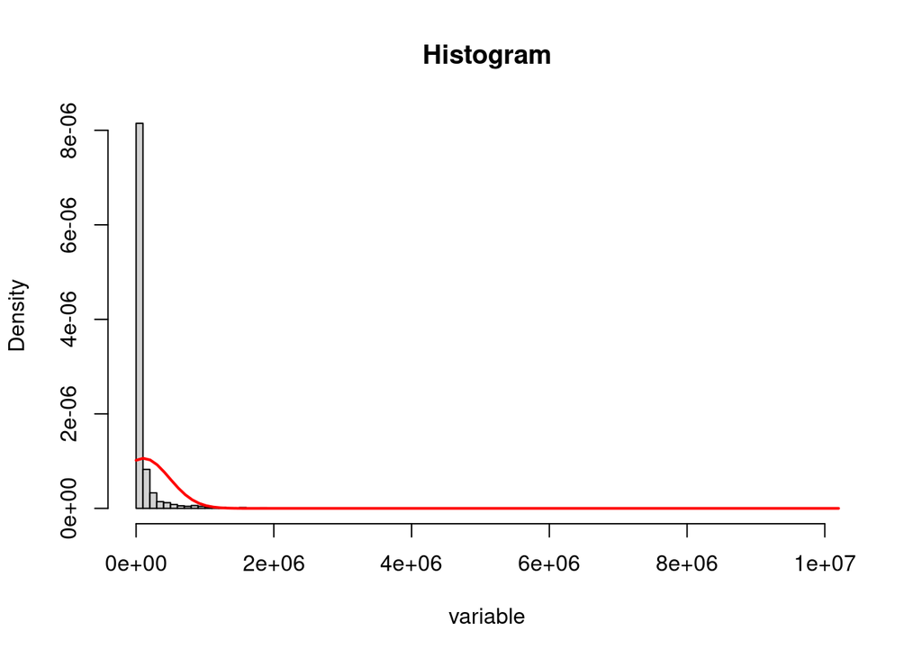

```r
hist(variable,freq = F,100, main = "Histogram")
curve(dnorm(x, mean = mm, sd = ss),col="red", lwd = 2, add=T)
```

```r
skewness(variable)
```

```
## [1] 14.70818
```

```r
shapiro.test(variable)
```

```
##
##  Shapiro-Wilk normality test
##
## data:  variable
## W = 0.22666, p-value < 2.2e-16
```

```r
calculate_outliers(variable)
```

```
## $num_outliers
## [1] 252
##
## $num_severe_outliers
## [1] 162
```

### Variable *povertypercent* :

Variable *povertypercent* is a numerical variable that expresses the percent of population in poverty and has no missing values.

Similarly to other variables, it has a skewed distribution with a larger right tail. It has 42 outliers, but none of them is severe. The p-value obtained in the shapiro_test confirms the rejection of the null hypothesis, concluding that the variable does not have a normal distribution.

```r
variable <- train$povertypercent;
summary <- summary(variable); summary
```

```
##    Min. 1st Qu.  Median    Mean 3rd Qu.    Max.
##    3.70   12.15   15.70   16.79   20.40   44.00
```

```r
mm <- mean(variable)
ss <- sd(variable)
range <- (summary[[6]] - summary[[1]]); range
```

```
## [1] 40.3
```

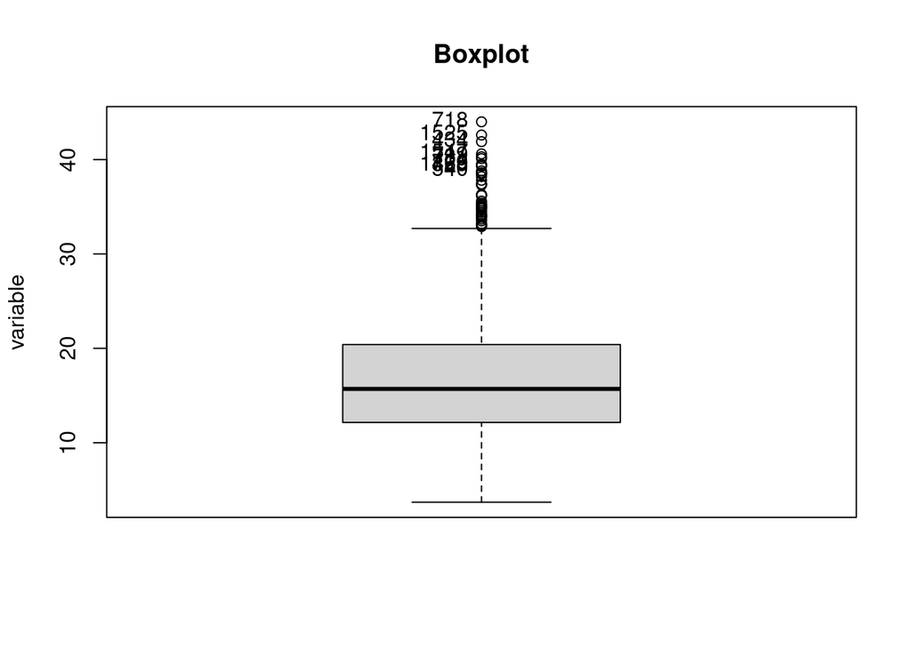

```
##  [1]  718 1525  434 1547  719  731  720 1468  329  540
```

```r
Boxplot(variable, main = "Boxplot")
```

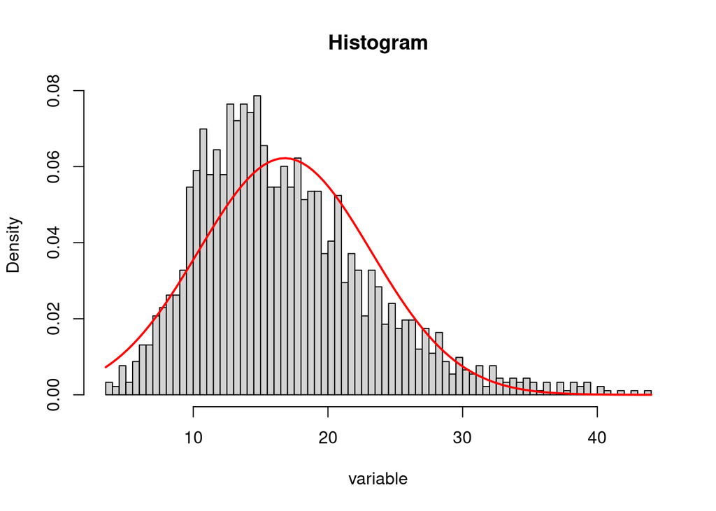

```r
hist(variable,freq = F,100, main = "Histogram")
curve(dnorm(x, mean = mm, sd = ss),col="red", lwd = 2, add=T)
```

```r
skewness(variable)
```

```
## [1] 0.8905168
```

```r
shapiro.test(variable)
```

```
##
##  Shapiro-Wilk normality test
##
## data:  variable
## W = 0.95557, p-value < 2.2e-16
```

```r
calculate_outliers(variable)
```

```
## $num_outliers
## [1] 42
##
## $num_severe_outliers
## [1] 0
```

### Variable *studypercap* : I CONSIDER IT IS WORTH TO REMOVE

Variable *studypercap* is a numerical variable that expresses “Per capita number of cancer-related clinical trials per county”.

It contains no missing values, and has 307 outliers (222 severe). Its distribution is non-symmetric. Note that 1162 out of 1831 observations contain value 0 in this variable, which indicates that it may only provide noise to the model. **Thus, we consider it is worth to remove the variable.**

```r
variable <- train$studypercap;
summary <- summary(variable); summary
```

```
##    Min. 1st Qu.  Median    Mean 3rd Qu.    Max.
##     0.0     0.0     0.0   148.2    76.0  9762.3
```

```r
length(variable[variable==0])
```

```
## [1] 1162
```

```r
mm <- mean(variable)
ss <- sd(variable)
range <- (summary[[6]] - summary[[1]]); range
```

```
## [1] 9762.309
```

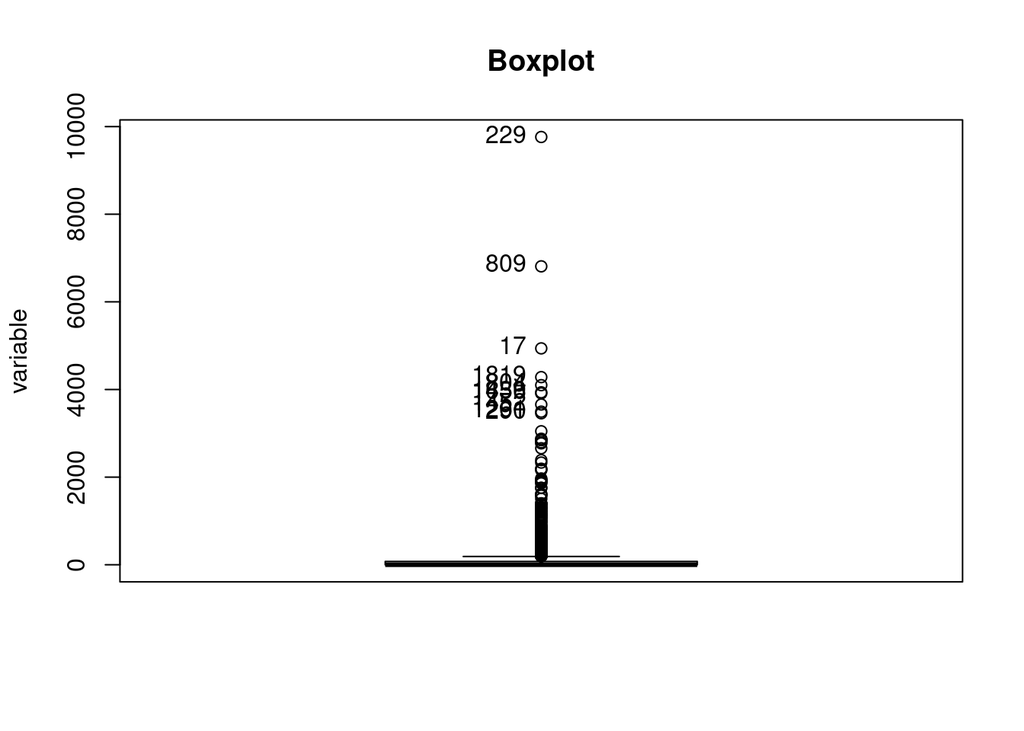

```
##  [1]  229  809   17 1819  804 1439 1656 1452 1261  290
```

```r
Boxplot(variable, main = "Boxplot")
```

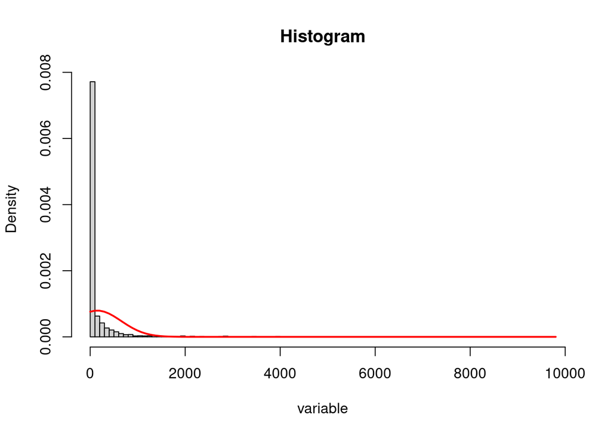

```r
hist(variable,freq = F,100, main = "Histogram")
curve(dnorm(x, mean = mm, sd = ss),col="red", lwd = 2, add=T)
```

```r
calculate_outliers(variable)
```

```
## $num_outliers
## [1] 307
##
## $num_severe_outliers
## [1] 222
```

### Variable *binnedi* : I CONSIDER IT IS WORTH TO REMOVE

– anna – I’ll remove the variable if we require precision or need the full detail of income differences but if we want to compare groups maybe is useful to keep it.

```r
variable <- train$binnedinc;
summary <- summary(variable); summary
```

```
##    Length     Class      Mode
##      1831 character character
```

```r
table(variable)
```

```
## variable
## (34218.1, 37413.8] (37413.8, 40362.7] (40362.7, 42724.4]   (42724.4, 45201]
##                172                164                172                194
##   (45201, 48021.6] (48021.6, 51046.4] (51046.4, 54545.6] (54545.6, 61494.5]
##                188                195                176                190
##  (61494.5, 125635]   [22640, 34218.1]
##                186                194
```

```r
prop.table(table(variable))
```

```
## variable
## (34218.1, 37413.8] (37413.8, 40362.7] (40362.7, 42724.4]   (42724.4, 45201]
##         0.09393774         0.08956854         0.09393774         0.10595303
##   (45201, 48021.6] (48021.6, 51046.4] (51046.4, 54545.6] (54545.6, 61494.5]
##         0.10267613         0.10649918         0.09612234         0.10376843
##  (61494.5, 125635]   [22640, 34218.1]
##         0.10158383         0.10595303
```

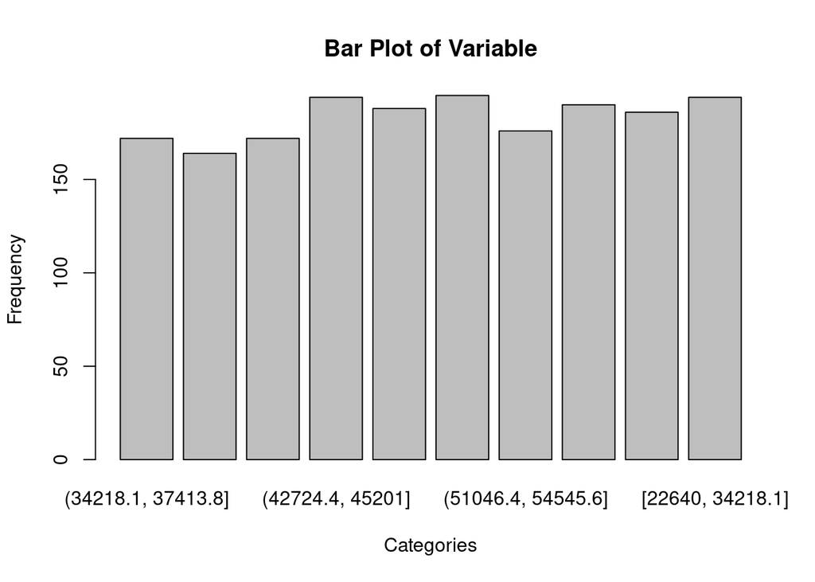

```r
barplot(table(variable), main="Bar Plot of Variable", xlab="Categories", ylab="Frequency")
```

### Variable *medianage* :

Medianage is a numerical variable that expresses the median age of county residents.

```r
variable <- train$medianage
summary <- summary(variable) ; summary
```

```
##    Min. 1st Qu.  Median    Mean 3rd Qu.    Max.
##   23.30   37.90   40.90   45.25   44.00  624.00
```

```r
calculate_outliers(variable)
```

```
## $num_outliers
## [1] 65
##
## $num_severe_outliers
## [1] 18
```

```r
variable[variable > 80] <- NA  # Replace values greater than 80 with NA
summary <- summary(variable) ; summary
```

```
##    Min. 1st Qu.  Median    Mean 3rd Qu.    Max.    NA's
##   23.30   37.90   40.90   40.85   43.80   59.00      18
```

```r
mm <- mean(variable)
ss <- sd(variable)
range <- (summary[[6]] - summary[[1]]); range
```

```
## [1] 35.7
```

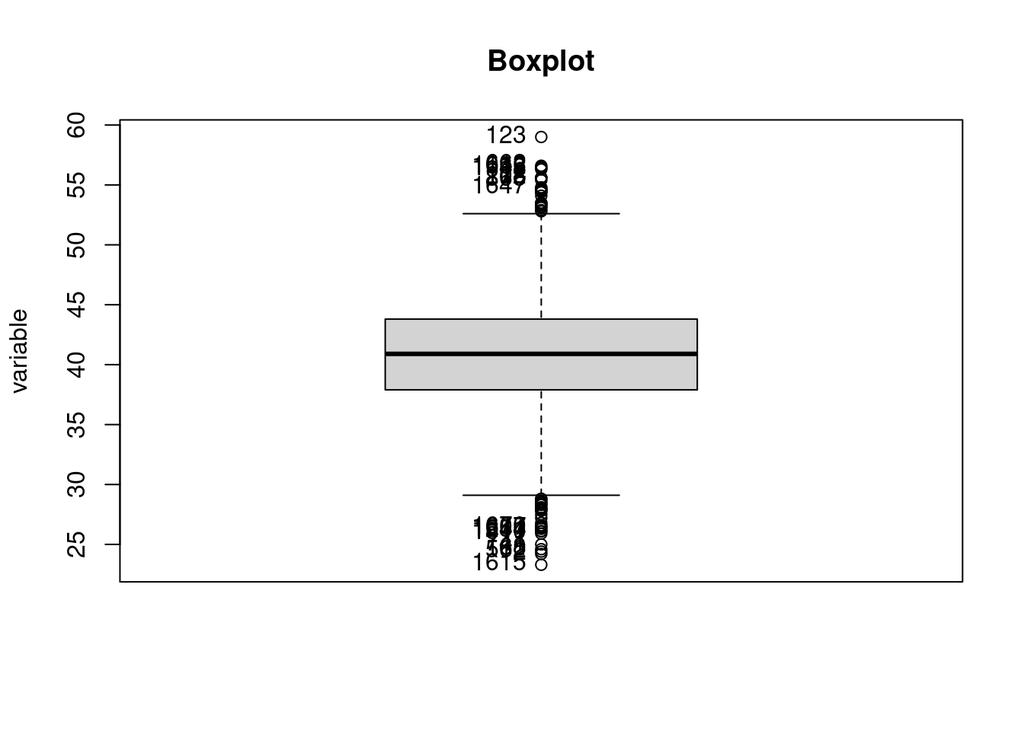

```
##  [1] 1615   12  562  168  741 1810  254 1641 1607 1670  123  662 1016  632 1148
## [16]  112  178  208  865 1647
```

```r
Boxplot(variable, main = "Boxplot")
```

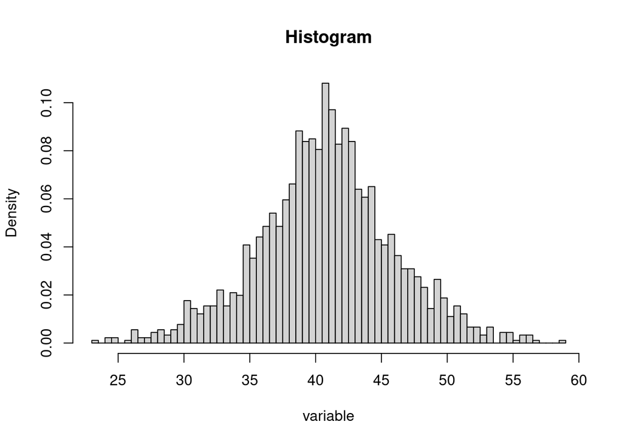

```r
hist(variable,freq = F,100, main = "Histogram")
curve(dnorm(x, mean = mm, sd = ss) ,col="red", lwd = 2, add=T)
```

```r
calculate_outliers(variable)
```

```
## $num_outliers
## [1] 52
##
## $num_severe_outliers
## [1] 18
```

```r
shapiro.test(variable)
```

```
##
##  Shapiro-Wilk normality test
##
## data:  variable
## W = 0.9951, p-value = 1.161e-05
```

### Variable *medianagemale* :

Numeric variable, represents the mean age of the male population of each county.

There are no missing values and it has 46 outliers, non of them several outliers. The mean is 39.59 yo and the median 39.50yo what suggest a simmetry distribution. After looking at the results of the shapiro-test it doesn’t have a normal distribution

```r
variable <- train$medianagemale
summary <- summary(variable) ; summary
```

```
##    Min. 1st Qu.  Median    Mean 3rd Qu.    Max.
##   23.00   36.40   39.50   39.59   42.60   60.20
```

```r
sum(is.nan(variable))
```

```
## [1] 0
```

```r
mm <- mean(variable)
ss <- sd(variable)
range <- (summary[[6]] - summary[[1]]); range
```

```
## [1] 37.2
```

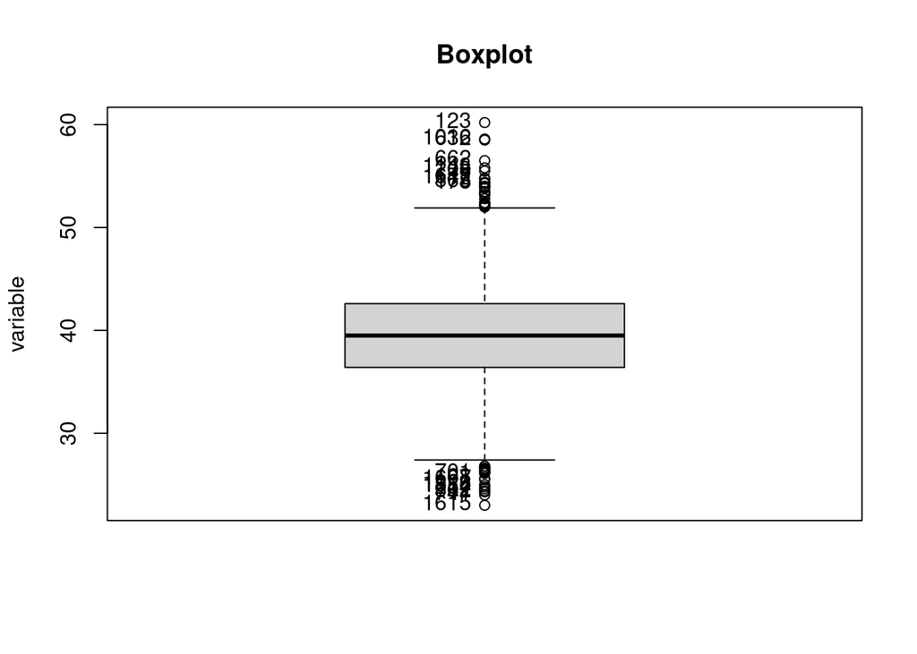

```
##  [1] 1615  741  562   12  254 1810 1223 1607  168  701  123 1016  632  662 1148
## [16]  208 1647  112  865  178
```

```r
Boxplot(variable, main = "Boxplot")
```

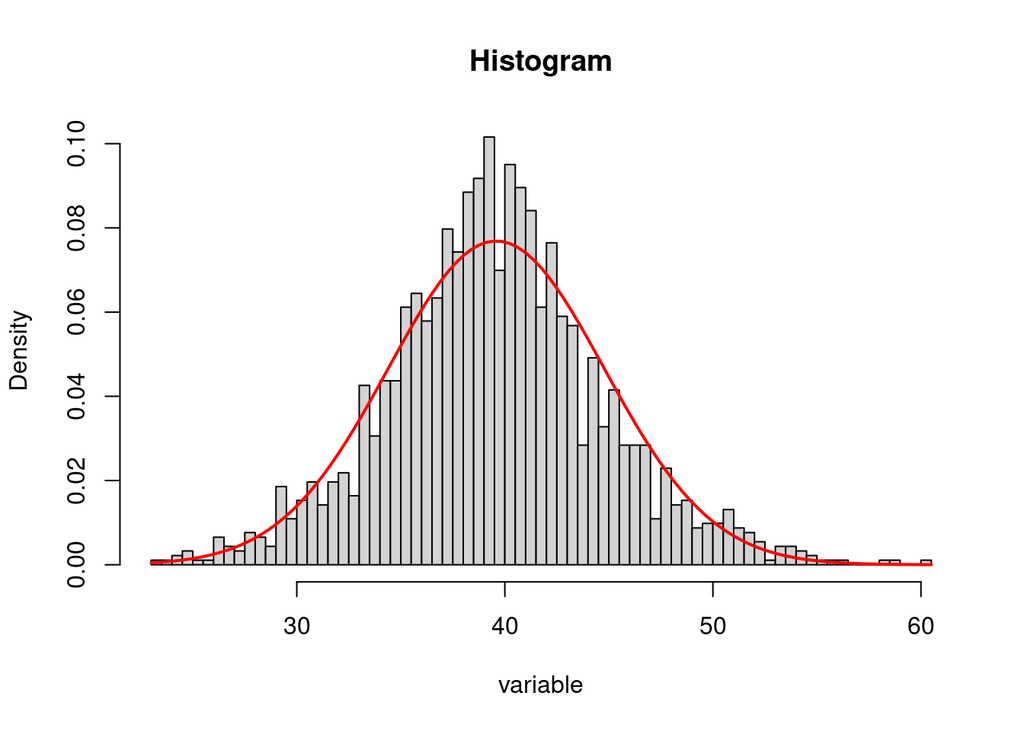

```r
hist(variable,freq = F,100, main = "Histogram")
curve(dnorm(x, mean = mm, sd = ss),col="red", lwd = 2, add=T)
```

```r
calculate_outliers(variable)
```

```
## $num_outliers
## [1] 46
##
## $num_severe_outliers
## [1] 0
```

```r
shapiro.test(variable)
```

```
##
##  Shapiro-Wilk normality test
##
## data:  variable
## W = 0.99404, p-value = 9.877e-07
```

### Variable *medianagefemale* : I AM NOT SURE IF IT’S WORTH IT TO SEPARATE THE MEDIANAGE WITH SEX

The medianagefemale is a numerical variable that analyze the median age of the females in each county.

It has a simmetric distribution (median=42.40, mean=42,17) but after analyzing the results of the Shapiro-test we observe that does not have a normal distribution.

```r
variable <- train$medianagefemale
summary <- summary(variable) ; summary
```

```
##    Min. 1st Qu.  Median    Mean 3rd Qu.    Max.
##   23.60   39.20   42.40   42.17   45.30   58.20
```

```r
sum(is.nan(variable))
```

```
## [1] 0
```

```r
mm <- mean(variable)
ss <- sd(variable)
range <- (summary[[6]] - summary[[1]]); range
```

```
## [1] 34.6
```

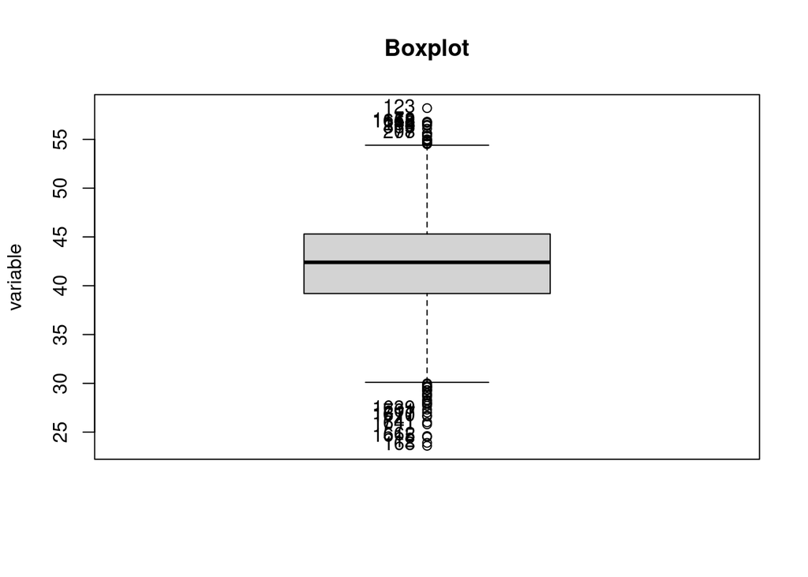

```
##  [1]  168   12 1615  562 1641  741 1670 1617  701 1639  123  178 1148  662 1658
## [16]  112  294  865   77  208
```

```r
Boxplot(variable, main = "Boxplot")
```

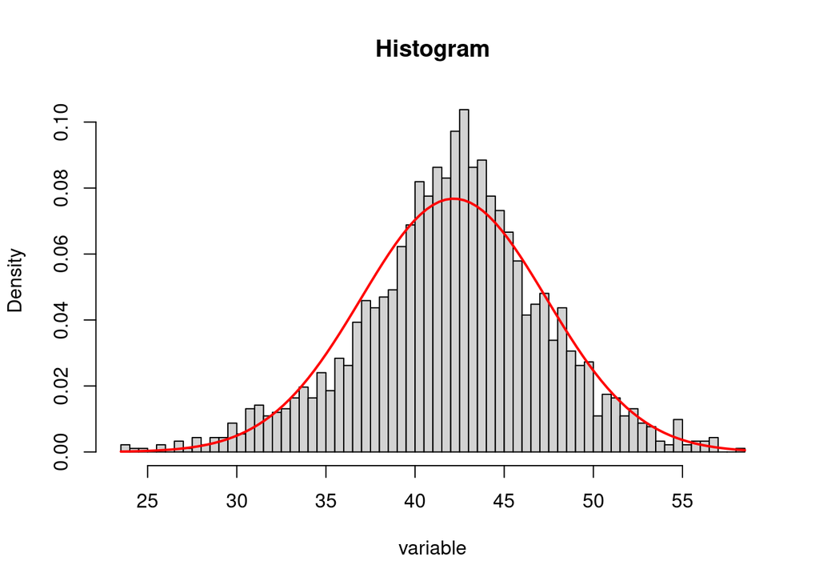

```r
hist(variable,freq = F,100, main = "Histogram")
curve(dnorm(x, mean = mm, sd = ss),col="red", lwd = 2, add=T)
```

```r
calculate_outliers(variable)
```

```
## $num_outliers
## [1] 55
##
## $num_severe_outliers
## [1] 0
```

```r
shapiro.test(variable)
```

```
##
##  Shapiro-Wilk normality test
##
## data:  variable
## W = 0.99321, p-value = 1.817e-07
```

### Variable *geography* :

Categorical variable that shows the name of each county. We can use this variable as a PK

–comment – Maybe we can separate the name of the state and create a new varible to be able to study the distribution around the United States

```r
variable <- train$geography;
summary <- summary(variable); summary
```

```
##    Length     Class      Mode
##      1831 character character
```

```r
table(variable)
```

[output not shown]

[output cut: 1778 more lines]

[output not shown]

### Variable *percentmarried*

Numerical variable that represent the percent of county residents who are married.

It has a non-symmetric distribution, it is skewed with a long left tail observed in the histogram. It doesn’t have missing values, it has 34 outliers (non of them severe) and they are concentrated on the lower end of the distribution. With the shapiro-test we can confirm the rejection of the null hypothesis, therefore it doesn’t have a normal distribution.

```r
variable <- train$percentmarried
summary <- summary(variable) ; summary
```

```
##    Min. 1st Qu.  Median    Mean 3rd Qu.    Max.
##    23.1    47.8    52.5    51.9    56.4    68.0
```

```r
sum(is.nan(variable))
```

```
## [1] 0
```

```r
mm <- mean(variable)
ss <- sd(variable)
range <- (summary[[6]] - summary[[1]]); range
```

```
## [1] 44.9
```

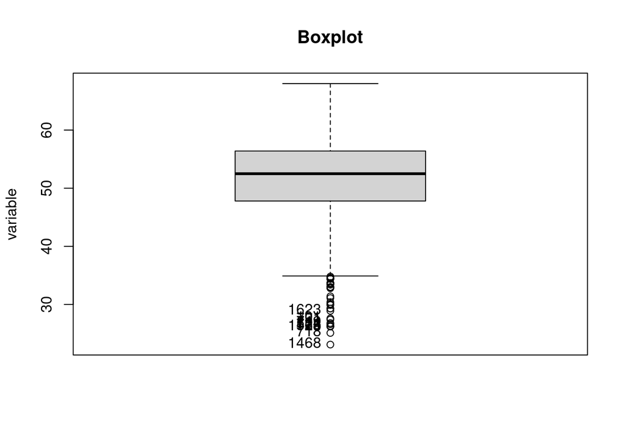

```
##  [1] 1468  718  168 1525  723  534  719  731  101 1623
```

```r
Boxplot(variable, main = "Boxplot")
```

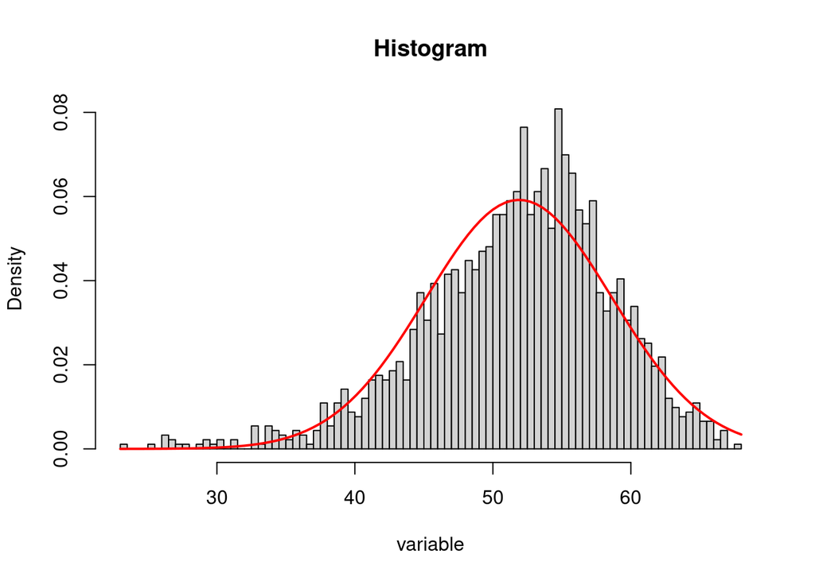

```r
hist(variable,freq = F,100, main = "Histogram")
curve(dnorm(x, mean = mm, sd = ss),col="red", lwd = 2, add=T)
```

```r
calculate_outliers(variable)
```

```
## $num_outliers
## [1] 34
##
## $num_severe_outliers
## [1] 0
```

```r
shapiro.test(variable)
```

```
##
##  Shapiro-Wilk normality test
##
## data:  variable
## W = 0.97753, p-value = 2.346e-16
```

### Variable *pctnohs18_24*

Numerical variable that show the percentage of county residents aged 18-24 whose highest level of education is less than a high school diploma.

The distribution of this variable is skewed with a long right tail, we can confirm that it doesn’t have a normal distribution thanks to the histogram and the curve. Moreover the p-value obtained in the shapiro-test confirm the non normal distribution. It doesn’t have misssing values, and it has 35 outliers, 5 of them severe.

```r
variable <- train$pctnohs18_24
summary <- summary(variable); summary
```

```
##    Min. 1st Qu.  Median    Mean 3rd Qu.    Max.
##    0.50   12.90   17.20   18.29   22.70   59.10
```

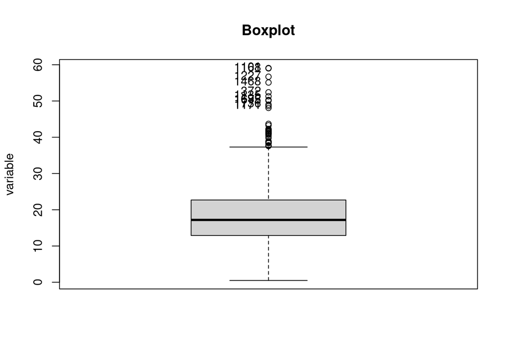

```
##  [1]  101 1168 1227 1468  372 1135 1692 1675 1736 1171
```

```r
mm <- mean(variable)
ss <- sd(variable)

Boxplot(variable, main="Boxplot")
```

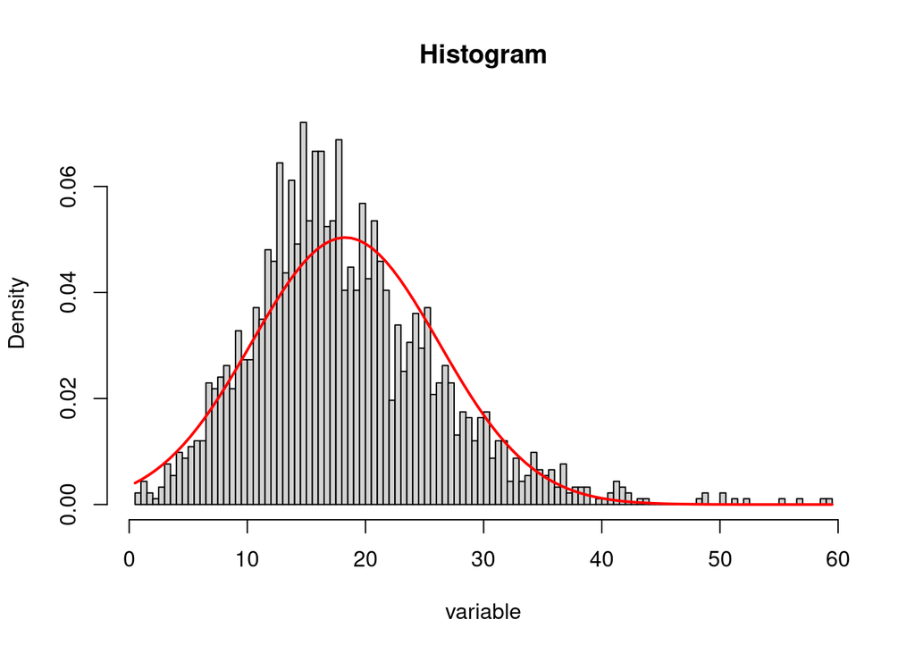

```r
hist(variable , freq=F, 100, main="Histogram")
curve(dnorm(x,mean=mm,sd=ss),col='red', lwd=2, add = T)
```

```r
calculate_outliers(variable)
```

```
## $num_outliers
## [1] 35
##
## $num_severe_outliers
## [1] 5
```

```r
shapiro.test(variable)
```

```
##
##  Shapiro-Wilk normality test
##
## data:  variable
## W = 0.96205, p-value < 2.2e-16
```

### Variable *ppcths18_24*

Numeric variable, it represent the percentage of county residents ages 18-24 highest education attained is a high school diploma.

We can observe with the median(34,7%) and the mean(35%) that the variable has a symmetric distribuition, but after the shapiro_test we observe that it doesn’t have a normal distribution. It doesn’t have missing values and it has 33 outliers, non of them severe.

```r
variable <- train$pcths18_24

summary <- summary(variable); summary
```

```
##    Min. 1st Qu.  Median    Mean 3rd Qu.    Max.
##     0.0    29.2    34.7    35.0    40.5    72.5
```

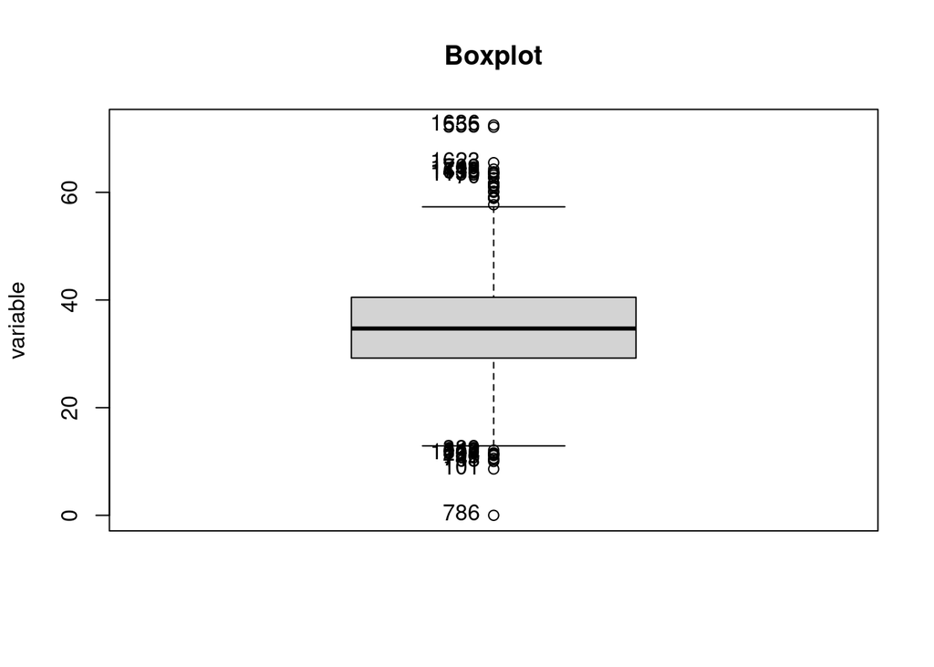

```
##  [1]  101  106  131  168  294  389  642  741  786 1810 1636  555 1623 1709  443
## [16] 1716  436 1699 1155   70
```

```r
mm <- mean(variable)
ss <- sd(variable)

Boxplot(variable, main="Boxplot")
```

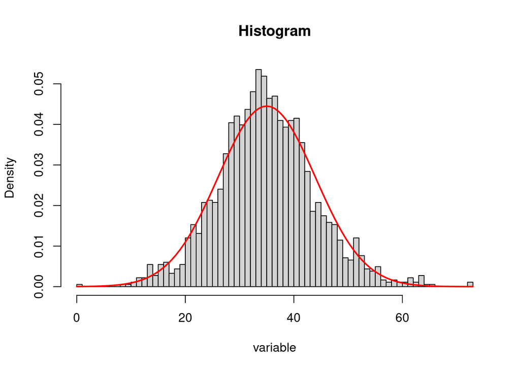

```r
hist(variable , freq=F, 100, main="Histogram")
curve(dnorm(x,mean=mm,sd=ss),col='red', lwd=2, add = T)
```

```r
calculate_outliers(variable)
```

```
## $num_outliers
## [1] 33
##
## $num_severe_outliers
## [1] 0
```

```r
shapiro.test(variable)
```

```
##
##  Shapiro-Wilk normality test
##
## data:  variable
## W = 0.99323, p-value = 1.922e-07
```